# TP3_logistic_regression_Fuentes_Nzalalemba

## TP3 : Logistic regression

The purpose of this tutorial is to implement and use the Logistic Regression for binary classification. We will apply this method to the problem of handwritten characters to learn how to distinguish two numbers (here 5 and 6).

```python
from pylab import *
#import numpy as np
#import matplotlib.pyplot as plt

from numpy import linalg as la
```

## 1. Logistic regression, IRLS algorithm.

### Preliminary question: the algorithm

#### Have a look at the function `regression_logistique.m` and locate the main steps of the algorithm you have been taught (see course).

You can comment the code in the cell below.

```python
def regression_logistique(X,t,Nitermax=20,eps_conv=1e-3):
    '''Entrees :
    X = [ones(N_train,1) x_train];
    t = class_train
    Nitermax = nombre maximale d'itérations (20 par défaut)
    eps_conv = critère de convergence sur norm(w-w_old)/norm(w) ;
    eps_conv=1e-3 par défaut

    Sorties :
    w : vecteur des coefficients de régression logistique
   Niter : nombre d'itérations utilisées effectivement

   Fonction de régression logistique pour la classification binaire.

   Utilisation :
       Nitermax = 50
       eps_conv = 1e-4
       [w,Niter] = regression_logistique(X,t,Nitermax,eps_conv)
    '''
    N_train = X.shape[0]

    #initialisation : 1 pas de l'algorithme IRLS
    w = np.zeros((X.shape[1],))
    w_old = w
    y = 1/2*np.ones((N_train,))
    R = np.diag(y*(1-y))   # diag(y_n(1-y_n))
    z = X.dot(w_old)-la.inv(R).dot(y-t)
    w = la.inv(X.T.dot(R).dot(X)).dot(X.T).dot(R).dot(z)

    # boucle appliquant l'algorithme de Newton-Raphson
    Niter = 1
    while ( (la.norm(w-w_old)/la.norm(w)>eps_conv) & (Niter<Nitermax) ):
        Niter = Niter+1
        y = 1/(1+np.exp(-X.dot(w)))
        R = np.diag(y*(1-y))
        w_old = w
        z = X.dot(w_old)-la.inv(R).dot(y-t)
        w = la.inv(X.T.dot(R).dot(X)).dot(X.T).dot(R).dot(z)

    return w, Niter
```

### Reading & preparing synthetic data

Load the training and test data sets `synth_train.txt` and `synth_test.txt`. The targets t belong to {1,2} and the features  
x belong to R^2.

We have 100 training samples and 200 test samples

- the 1st column contains the label of each sample,
- columns 2 and 3 contain the coordinate of each point.

```python
# Training set
synth_train = np.loadtxt('synth_train.txt')
class_train = synth_train[:,0]
class_train_1 = np.where(synth_train[:,0]==1)[0]
class_train_2 = np.where(synth_train[:,0]==2)[0]
x_train = synth_train[:,1:]
N_train = np.size(x_train,axis=0)

# Test set
synth_test = np.loadtxt('synth_test.txt')
class_test = synth_test[:,0]
class_test_1 = np.where(synth_test[:,0]==1)[0]
class_test_2 = np.where(synth_test[:,0]==2)[0]
x_test = synth_test[:,1:]
N_test = np.size(x_test,axis=0)
```

### Preparing features for logistic regression (binary classification)

First, we prepare the feature matrix and the target vector associated to the training and test sets:

```python
X = np.hstack((np.ones((N_train,1)),x_train))
t = 2-class_train   # 0 if class=2, 1 if class=1

X_test = np.hstack((np.ones((N_test,1)),x_test))
t_test = 2-class_test   # 0 if class=2, 1 if class=1
```

### Exercise 1 : the logistic function of decision

1. Use the function `regression_logistique.m` to estimate the logistic regression vector `w`. Indication : use

   ```
   Nitermax = 50;
   eps_conv=1e-3;
   ```

   .
2. Compute the decision function $f(x) = argmax_k P(C_k|x)$ on the test set to get the classification results. Recall that $y_n=\sigma(w^T x)$ (logistic function) and that *using vectors* you may directly write $y=\sigma(Xw)$, with the column of ones in X.
3. Display the results by plotting the points from both the training set and the test set.
4. Write the equation which defines the decision boundary.
5. Artificially add a few points to the training set far from the decision boundary to check the robustness of logistic regression to outliers. Check the behaviour of LDA for comparison in this case and comment.

#### 1. Estimation of w

```python
#Exercise 1
Nitermax = 50; eps_conv=1e-3;
# w, Niter = regression_logistique(X, t)
[w,Niter] = regression_logistique(X,t,Nitermax,eps_conv)

"""
To estimate the parameter w, we are using the Iterated Reweighted Least Squares (IRLS) algorithm, also known as
the Newton-Raphson algorithm, to find a numerical solution of the logistic regression optimization problem.
"""
print("We find w = ", w, "after ", Niter, "iterations.")

"""
Here, w is equivalent to w_tilde which is composed of the intercept w0 and w_i coefficient of each feature x_i.
"""
```

```
We find w =  [-15.206658    -7.91866363   6.56243114] after  9 iterations.
```

```
'\nHere, w is equivalent to w_tilde which is composed of the intercept w0 and w_i coefficient of each feature x_i.\n'
```

#### 2. Decision function on the test set

```python
y_n = 1/(1+np.exp(-X_test.dot(w)))

"""
Note that the decision fonction is the logistic function where the activation is a=w^Tx
"""
```

```
'\nNote that the decision fonction is the logistic function where the activation is a=w^Tx\n'
```

#### 3.1. Decision boundary on the test displayed with training data

```
'\nIt is clear that, although the decision function is non-linear, the decision boundary is linear.\n'
```

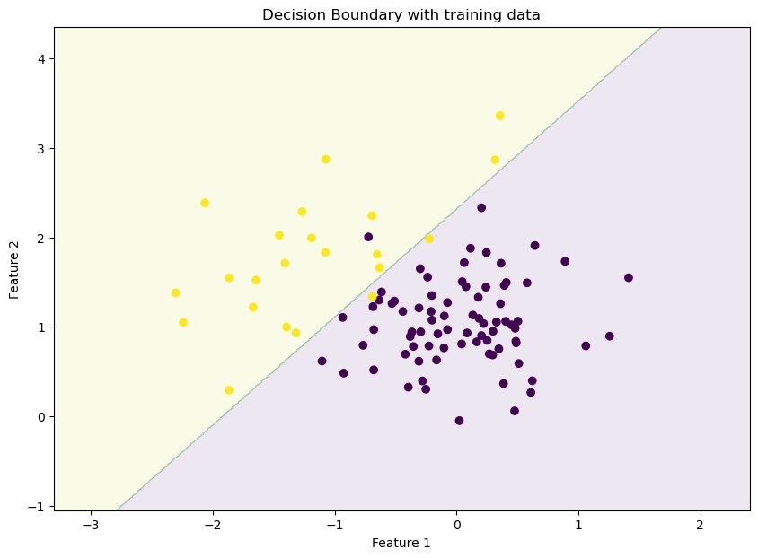

```python
# To Plot the Decision Boundary for LDA
arr1 = np.arange(x_train[:, 0].min()-1, x_train[:, 0].max()+1, 0.01)
arr2 = np.arange(x_train[:, 1].min()-1, x_train[:, 1].max()+1, 0.01)


xx, yy = np.meshgrid(arr1, arr2)
input_arr = np.array([xx.ravel(), yy.ravel()]).T
N_input = np.size(input_arr,axis=0)
input_array = np.hstack((np.ones((N_input,1)),input_arr))

# For the prediction
# labels = clf.predict(input_array)
labels = np.where(1/(1+np.exp(-input_array.dot(w)))> 0.5, 1, 0)

plt.figure(figsize =(10, 7))
plt.contourf(xx, yy, labels.reshape(xx.shape), alpha = 0.1)
plt.scatter(x_train[:, 0], x_train[:, 1], c = t.ravel(), alpha = 1)
plt.xlabel('Feature 1')
plt.ylabel('Feature 2')
plt.title('Decision Boundary with training data')

"""
It is clear that, although the decision function is non-linear, the decision boundary is linear.
"""
```

Using, Professor's code:

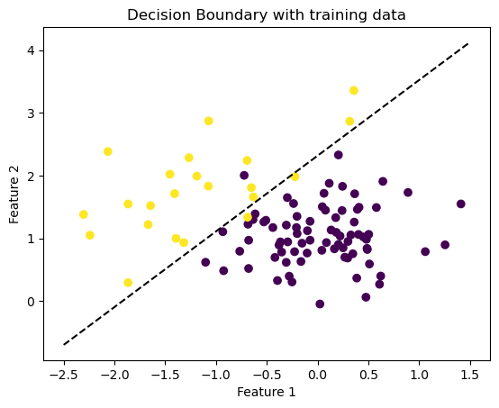

```python
x1 = np.linspace(-2.5,1.5,10)
x2 = (-w[0]-w[1]*x1)/w[2]
plt.plot(x1,x2,'k--')
plt.scatter(x_train[:, 0], x_train[:, 1], c = t.ravel(), alpha = 1)
plt.xlabel('Feature 1')
plt.ylabel('Feature 2')
plt.title('Decision Boundary with training data')
```

#### 3.2. Decision boundary on the test displayed with test data

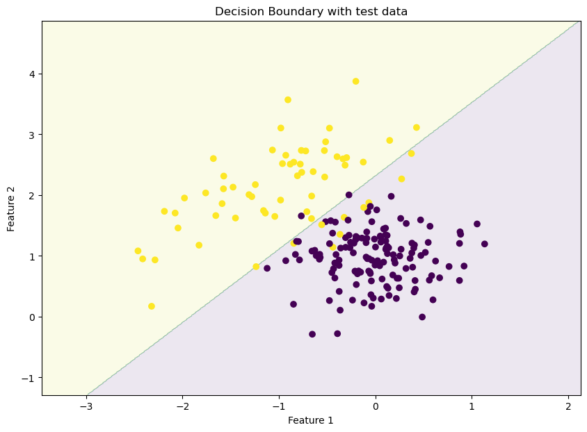

```python
# To Plot the Decision Boundary for LDA
arr1 = np.arange(x_test[:, 0].min()-1, x_test[:, 0].max()+1, 0.01)
arr2 = np.arange(x_test[:, 1].min()-1, x_test[:, 1].max()+1, 0.01)


xx, yy = np.meshgrid(arr1, arr2)
input_arr = np.array([xx.ravel(), yy.ravel()]).T
N_input = np.size(input_arr,axis=0)
input_array = np.hstack((np.ones((N_input,1)),input_arr))

# For the prediction
# labels = clf.predict(input_array)
labels = np.where(1/(1+np.exp(-input_array.dot(w)))> 0.5, 1, 0)

plt.figure(figsize =(10, 7))
plt.contourf(xx, yy, labels.reshape(xx.shape), alpha = 0.1)
plt.scatter(x_test[:, 0], x_test[:, 1], c = t_test.ravel(), alpha = 1)
plt.xlabel('Feature 1')
plt.ylabel('Feature 2')
plt.title('Decision Boundary with test data')
```

Using, Professor's code:

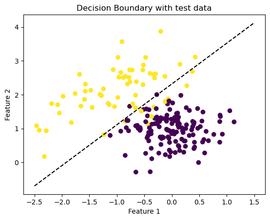

```python
x1 = np.linspace(-2.5,1.5,10)
x2 = (-w[0]-w[1]*x1)/w[2]
plt.plot(x1,x2,'k--')
plt.scatter(x_test[:, 0], x_test[:, 1], c = t_test.ravel(), alpha = 1)
plt.xlabel('Feature 1')
plt.ylabel('Feature 2')
plt.title('Decision Boundary with test data')
```

#### 4. The equation which defines the decision boundary.

```python
"""
The decision function is non-linear in case of the logistic regression problem.
However the decision boundary is defined by a hyperplane which geneal expression is w^Tx + w0 = 0
Therefore, one can write the decison boundary as follows: $w_tilde^Tx = 0$
"""
```

```
'\nThe decision function is non-linear in case of the logistic regression problem.\nHowever the decision boundary is defined by a hyperplane which geneal expression is w^Tx + w0 = 0\nTherefore, one can write the decison boundary as follows: $w_tilde^Tx = 0$\n'
```

#### 5.1. Checking robustness of logistic regression in presence of outliers

```python
# Introducing outliers

np.random.seed(21) # Fixed seed for reproducibility of the results

"""
We chose to add 20 outliers which are random numbers from a uniform distribution between 10 and 20.
We also fexed the seed of the numpy random numbers generator for reproducibility of the results.
"""
# Introducing outliers features
x_outliers = np.random.uniform(10, 20, size=(20, 2))
x_train_outliers = np.vstack((x_outliers,x_train))
N_train_outliers = np.size(x_train_outliers,axis=0) # Total number of features (training data + outliers)
X = np.hstack((np.ones((N_train_outliers,1)),x_train_outliers))


"""
Since we are talking about ouliers, we randomly assigned classes to them.
"""
# Assigning classes to outliers features
t_outliers = np.random.randint(2, size=(20, 1))
t_train_outliers = np.vstack((t_outliers,t.reshape(100,1)))
```

```python
# Estimation of w
Nitermax = 50; eps_conv=1e-3;
# w, Niter = regression_logistique(X, t)
[w,Niter] = regression_logistique(X,t_train_outliers.ravel(),Nitermax,eps_conv)

"""
We perform the estimation of the regression parameter w taking into account the outliers to see how robust
is regression_logistique.m in presence of outliers.
"""
```

```
'\nWe perform the estimation of the regression parameter w taking into account the outliers to see how robust\nis regression_logistique.m in presence of outliers.\n'
```

```
'\nTo plot this figure, we are using the new estimation of w obtained in the presence of outliers.\n'
```

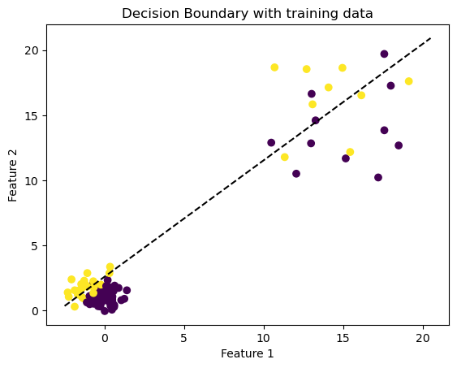

```python
# The decision boundary with training data
x1 = np.linspace(-2.5,20.5,10)
x2 = (-w[0]-w[1]*x1)/w[2]
plt.plot(x1,x2,'k--')
plt.scatter(x_train_outliers[:, 0], x_train_outliers[:, 1], c = t_train_outliers.ravel(), alpha = 1)
plt.xlabel('Feature 1')
plt.ylabel('Feature 2')
plt.title('Decision Boundary with training data')

"""
To plot this figure, we are using the new estimation of w obtained in the presence of outliers.
"""
```

```
'\nTo plot this figure, we are using the new estimation of w obtained in the presence of outliers.\n'
```

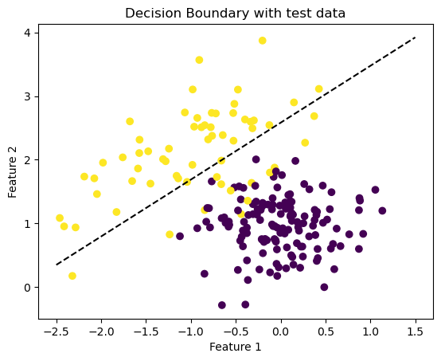

```python
# The decision boundary with test data
x1 = np.linspace(-2.5,1.5,10)
x2 = (-w[0]-w[1]*x1)/w[2]
plt.plot(x1,x2,'k--')
plt.scatter(x_test[:, 0], x_test[:, 1], c = t_test.ravel(), alpha = 1)
plt.xlabel('Feature 1')
plt.ylabel('Feature 2')
plt.title('Decision Boundary with test data')

"""
To plot this figure, we are using the new estimation of w obtained in the presence of outliers.
"""
```

```python
"""
In the presence of outliers, logistic regression algorithm seems to perform well. It is robust to outliers.
"""
```

```
'\nIn the presence of outliers, logistic regression algorithm seems to perform well. It is robust to outliers.\n'
```

#### 5.2. Checking robustness of LDA in presence of outliers

```python
# Indices of features belonging to each class (0,1)
indiceC1_train = np.nonzero(t_train_outliers.ravel()==1)
indiceC0_train = np.nonzero(t_train_outliers.ravel()==0)

# Features split as per class
X_C1_train=x_train_outliers[indiceC1_train].T # Features of class 1
X_C0_train=x_train_outliers[indiceC0_train].T # Features of class 0

# Number of features per class
N1_train = np.size(X_C1_train,axis=1) # Number of features of class 1
N0_train = np.size(X_C0_train,axis=1) # Number of features of class 0
```

```python
# LDA Maximum likelihood estimates computation
# Estimation of weights pi_1 and pi_2 for each class
pi_1 = N1_train/N_train_outliers # For class 1
pi_0 = N0_train/N_train_outliers # For class 0

# Estimation of empirical means mu_1 and mu_2 for each class
mu_1 = (X_C1_train.sum(1))/N1_train # Same as "mu_1 = X1_train.mean(1)"
mu_0 = (X_C0_train.sum(1))/N0_train # Same as "mu_2 = X2_train.mean(1)"

mu_1=mu_1.reshape(2,1)
mu_0=mu_0.reshape(2,1)


# Estimation of empirical covariance matrices sigma_1 and sigma_2
sigma_1 = ((X_C1_train - mu_1).dot((X_C1_train - mu_1).T))/N1_train # The same as "sigma_1 = np.cov(X1_train.T, ddof=0)"
# sigma_1 = (np.matmul((X_C1_train-mu_1),(X_C1_train-mu_1).T))/N1_train
sigma_0 = ((X_C0_train - mu_0).dot((X_C0_train - mu_0).T))/N0_train # The same as "sigma_2 = np.cov(X2_train.T, ddof=0)"

# sigma_2 = (np.matmul((X_C2_train-mu_2),(X_C2_train-mu_2).T))/N2_train

# Computation of the common averaged covariance sigma (average of intra-class covariances)
sigma = (N1_train*sigma_1 + N0_train*sigma_0)/N_train_outliers
```

```python
# Computation of log-probabilities of belonging to each class
# We keep only dependance on the classes 1 and 2
log_proba_1 = mu_1.T.dot(inv(sigma)).dot(X_C1_train) - (1/2)*mu_1.T.dot(inv(sigma)).dot(mu_1) + log(pi_1)
log_proba_0 = mu_0.T.dot(inv(sigma)).dot(X_C0_train) - (1/2)*mu_0.T.dot(inv(sigma)).dot(mu_0) + log(pi_0)

# Decision of classification
# Linear parameters for the decision function 1
w1 = inv(sigma).dot(mu_1)
w01 = - (1/2)*mu_1.T.dot(inv(sigma)).dot(mu_1) + log(pi_1)

# Linear parameters for the decision function 2
w2 = inv(sigma).dot(mu_0)
w02 = - (1/2)*mu_0.T.dot(inv(sigma)).dot(mu_0) + log(pi_0)
```

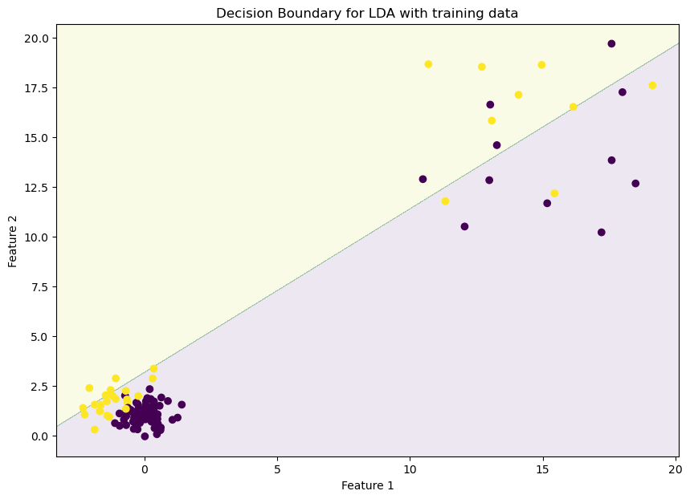

```python
# To Plot the Decision Boundary for LDA
arr1 = np.arange(x_train_outliers[:, 0].min()-1, x_train_outliers[:, 0].max()+1, 0.01)
arr2 = np.arange(x_train_outliers[:, 1].min()-1, x_train_outliers[:, 1].max()+1, 0.01)


xx, yy = np.meshgrid(arr1, arr2)
input_array = np.array([xx.ravel(), yy.ravel()]).T

# For the prediction
f_X_1_dec_func = w1.T.dot(input_array.T) + w01
f_X_2_dec_func = w2.T.dot(input_array.T) + w02

labels = np.where(f_X_1_dec_func.T > f_X_2_dec_func.T, 1, 0) # The predictions

# Plotting the Decision boundary using training data
plt.figure(figsize =(10, 7))
plt.contourf(xx, yy, labels.reshape(xx.shape), alpha = 0.1)
plt.scatter(x_train_outliers[:, 0], x_train_outliers[:, 1], c = t_train_outliers.ravel(), alpha = 1)
plt.xlabel('Feature 1')
plt.ylabel('Feature 2')
plt.title('Decision Boundary for LDA with training data')
```

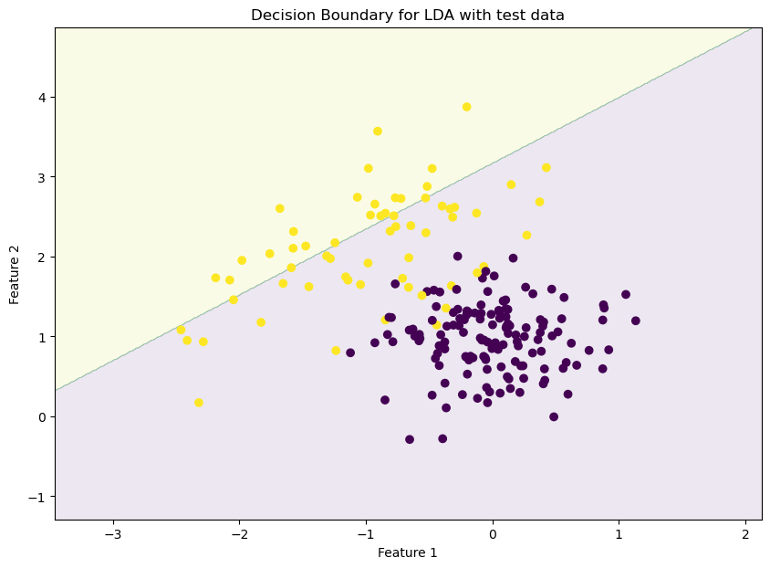

```python
# To Plot the Decision Boundary for LDA
arr1 = np.arange(x_test[:, 0].min()-1, x_test[:, 0].max()+1, 0.01)
arr2 = np.arange(x_test[:, 1].min()-1, x_test[:, 1].max()+1, 0.01)


xx, yy = np.meshgrid(arr1, arr2)
input_array = np.array([xx.ravel(), yy.ravel()]).T

# For the prediction
f_X_1_dec_func = w1.T.dot(input_array.T) + w01
f_X_2_dec_func = w2.T.dot(input_array.T) + w02

labels = np.where(f_X_1_dec_func.T > f_X_2_dec_func.T, 1, 0) # The predictions

# Plotting the Decision boundary using test data
plt.figure(figsize =(10, 7))
plt.contourf(xx, yy, labels.reshape(xx.shape), alpha = 0.1)
plt.scatter(x_test[:, 0], x_test[:, 1], c = t_test.ravel(), alpha = 1)
plt.xlabel('Feature 1')
plt.ylabel('Feature 2')
plt.title('Decision Boundary for LDA with test data')
```

```python
"""
In the presence of outliers, LDA algorithm seems to perform bad. It is not robust to outliers.
"""
```

```
'\nIn the presence of outliers, LDA algorithm seems to perform bad. It is not robust to outliers.\n'
```

#### 5.3. Comparison and Comments

```python
# Test Error of LOGISTIC REGRESSION
# Decision of classification using Logistic Regression
predictions = np.where(1/(1+np.exp(-X_test.dot(w)))> 0.5, 1, 0)

error_Log_Reg = 1-mean(t_test == predictions)
print("The test error of logistic regression taking into account the outliers is", error_Log_Reg)

# Test Error of LDA
# We compute the hyperplanes for seperation of regions between classes
f_X_1 = w1.T.dot(x_test.T) + w01
f_X_2 = w2.T.dot(x_test.T) + w02

# Decision of classification using LDA
decision_vector = np.where(f_X_1.T > f_X_2.T, 1, 0)


error_LDA = 1-mean(t_test == decision_vector)
print("The test error of LDA taking into account the outliers is", error_LDA)


"""
We can notice that the test error using logistic regression is much lower than the one using LDA.
When, in the presence of outliers, the test error of logistic regression is 7%, the one of LDA is 35%
Therfore, from the above results, we can say that logistic regression is robust in presence of outliers,
however, LDA is not robust to outliers.
"""
```

[output not shown]

[output not shown]

#### Conclusion: Logistic regression is performing better than LDA in presence of ouliers

## 2. Application: handwritten digits recognition 5 & 6

We load 2 matrices which contain each a sequence of examples of 16x16 images of handwritten digits which are 5 and 6 here. Each line of the matrix contains 256 pixel values coding for the gray level of a 16x16 image.

```python
train_5 = np.loadtxt('train_5.txt',delimiter=',')   # 556 samples
train_6 = np.loadtxt('train_6.txt',delimiter=',')   # 664 samples
```

### Examples of images

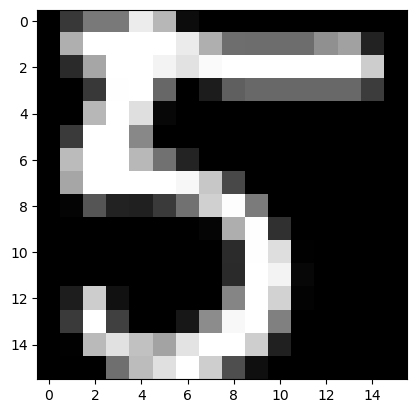

```python
# Digit 5
n=9;
I = np.reshape(train_5[n,:],(16,16))

plt.imshow(I,cmap='gray')
plt.show()
```

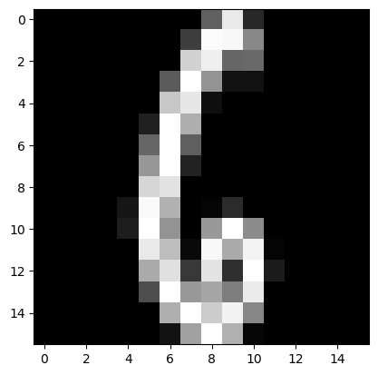

```python
# Digit 6
n=5;
I = reshape(train_6[n,:],(16,16))

plt.imshow(I,cmap='gray')
plt.show()
```

### Separating the training and test sets

We keep in the training set the 145 first images of 5s and the 200 first images of 6s:

```python
'''

1. Concatenate images of 5 and 6.
2. Generate array of 1s to put label in all observations.
3. Now put 0 in the label of all 145 first observations, beloinging to the images of number 5.
4. We end up with a separete array for the x's and the labels. x_train_brut that contains observations of the images of both numbers 5 and 6,
and class_train that contains their respective labels 0 and 1.

'''
x_train_brut = np.vstack((train_5[:145,:], train_6[:200,:]))
N_train = np.size(x_train_brut,axis=0)
class_train = np.ones((345,1))   # label 1 for digit 6
class_train[:145] = 0       # label 0 for digit 5

x_test_brut = np.vstack((train_5[145:,:], train_6[200:,:]))
N_test = np.size(train_5,axis=0)+np.size(train_6,axis=0)-N_train
class_test = np.ones((N_test,1))   # label 1 for digit 6
class_test[:(556-145)] = 0       # label 0 for digit 5
```

## Exercise 2: logistic regression to classify 5 & 6

1. Note that pixel values are between -1 and 1 by using the functions `min(I(:))` and `max(I(:))`.
2. Identify the indices of the most significant pixels, which are defined as having a standard deviation greater than 0.5 here. We denote by `lis_sig` the list of positions of these significant pixels in the image vector. _Indication : the function `std` gives the standard deviation (columnwise in matrices) and you should find 173 pixel positions.
3. Show a binary image to locate these pixels. _Indication : `Isig = zeros(16); Isig(list_sig)=1; Isig=Isig';`._
4. Define the training set `x_train` from `x_train_brut` from the significant pixels only.
5. Do the same with `x_test_brut` to extract `x_test`.
6. Use `regression_logistique.m` to estimate the logistic regression vector `w` from the training set `x_train`. Choose `Nitermax = 13; eps_conv = 1e-3;`
7. Compute the decision function and the labels of the test set `x_test`. *Indication : do not forget the column of ones !*
8. Estimate the classification error rate by using : `erreur = sum(abs(class-class_test))/N_test;`.
9. Locate some misclassified examples and visualize the corresponding image. Comment on your results and observations.

#### 1. Value of the pixels

```python
print(f'We can observe that the minimum value of the pixels in the whole dataset is {np.vstack((train_5, train_6)).min()} and the maximum is {np.vstack((train_5, train_6)).max()}')
```

```
We can observe that the minimum value of the pixels in the whole dataset is -1.0 and the maximum is 1.0
```

#### 2. Most significant pixels

```python
# Getting standard deviation by pixel
std_by_pixel=np.std(x_train_brut, axis=0)
```

```python
# index of significant pixels
list_sig = np.where(std_by_pixel > 0.5)[0]

len(list_sig) #we get 173 significant pixels out of 256. So the images can be "summarized" just in 173 of them.
```

```
173
```

#### 3. Binary image with most significant pixels

```python
# Create an array of 256 elements filled with 0 (just black pixels).
picture_sig = np.zeros(256, dtype=int)

# Replace with -1 the most significant pixels so that we can visualize in white the relevant ones.
picture_sig[list_sig] = 1
```

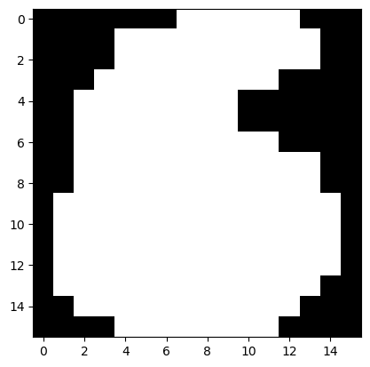

```python
# binary image with most significant pixels
I = reshape(picture_sig,(16,16))

plt.imshow(I,cmap='gray')
plt.show()
```

#### 4. Define train dataset with significant pixels

```python
# we index all rows to maintain all samples, and filter columns of the matrix to keep only relevant indexes
x_train=x_train_brut[:,list_sig]
```

```python
# the resulting matrix has only 173 pixels as we discused previously
x_train.shape
```

```
(345, 173)
```

#### 5. Define test dataset with significant pixels

```python
# we index all rows to maintain all samples, and filter columns of the matrix to keep only relevant indexes
x_test=x_test_brut[:,list_sig]
```

```python
# the resulting matrix has only 173 pixels as we discused previously
x_test.shape
```

```
(875, 173)
```

#### 6. Calling newton raphson function to estimate the w's of the sigmoide function

```python
X = np.hstack((np.ones((N_train,1)),x_train))

# estimating the w's of our sigmoide function
w,Niter=regression_logistique(X,class_train.ravel(),13,1e-3)
```

#### 7. Compute the decision function, and make predictions

```python
X_test=np.hstack((np.ones((N_test,1)),x_test))

y_sigmoide=1/(1+exp(-np.dot(X_test,w.reshape(174,1))))
```

```python
# computing thhe labels of the images in the test set, using as threshold 0.5
decision_vector_test=np.where(y_sigmoide>0.5,1,0)
```

#### 8. Estimate the test error

```python
# computing the error on the test set
print(f'error on the test set {(1-np.mean(decision_vector_test==class_test))*100}%')
```

```
error on the test set 7.885714285714284%
```

#### 9. Missclassified observations

```python
# get index of all images that were missclassified
missclassified_indexes = np.where(decision_vector_test != class_test)[0]
```

```python
# grab the pixels of the first missclassified image
missclassified_image=x_test_brut[missclassified_indexes[0],:]
```

```
below we can see the image of one missclassified observation. Which its true value is 5
```

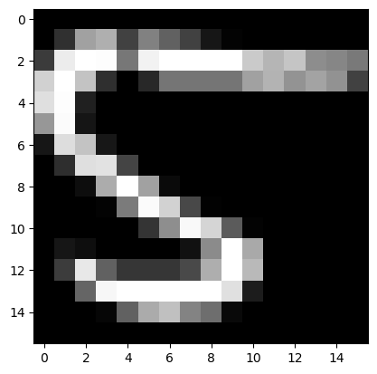

```
However, the model said this image was 6
```

```python
# plot missclassified image

print(f'below we can see the image of one missclassified observation. Which its true value is {5 if class_test[missclassified_indexes[0]][0] == 0 else 6}')

I = reshape(missclassified_image,(16,16))

plt.imshow(I,cmap='gray')
plt.show()

print()

print(f'However, the model said this image was {5 if decision_vector_test[missclassified_indexes[0]][0] == 0 else 6}')
```

```
below we can see the image of one missclassified observation. Which its true value is 5
```

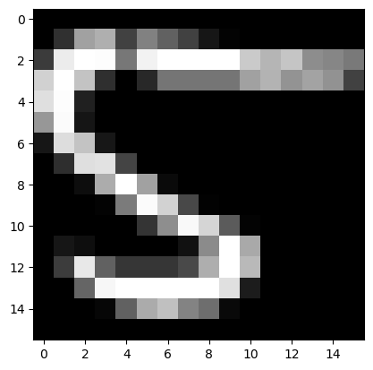

```
However, the model said this image was 6


below we can see the image of one missclassified observation. Which its true value is 5
```

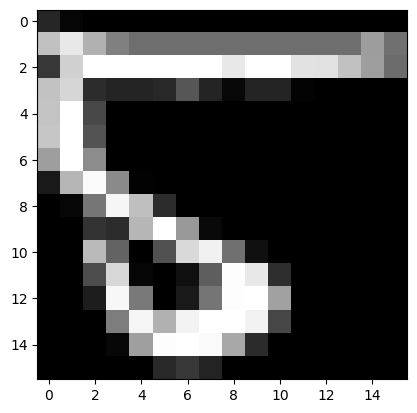

```
However, the model said this image was 6


below we can see the image of one missclassified observation. Which its true value is 5
```

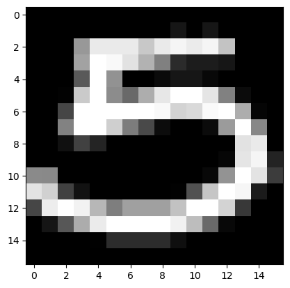

```
However, the model said this image was 6


below we can see the image of one missclassified observation. Which its true value is 5
```

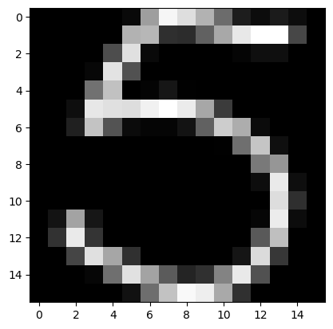

```
However, the model said this image was 6


below we can see the image of one missclassified observation. Which its true value is 5
```

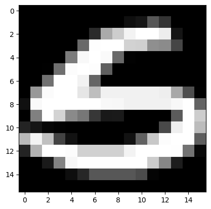

```
However, the model said this image was 6


below we can see the image of one missclassified observation. Which its true value is 5
```

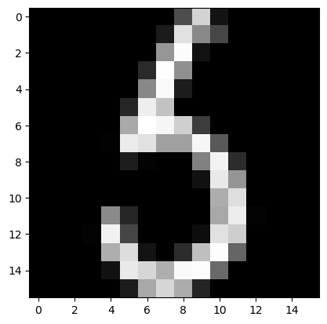

```
However, the model said this image was 6


below we can see the image of one missclassified observation. Which its true value is 5
```

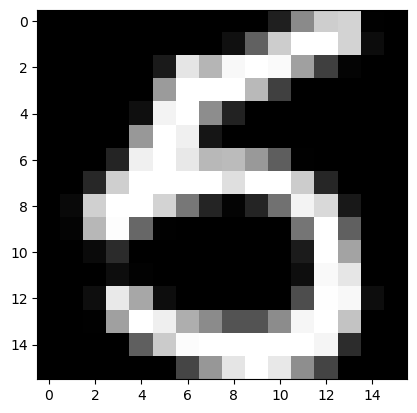

```
However, the model said this image was 6


below we can see the image of one missclassified observation. Which its true value is 5
```

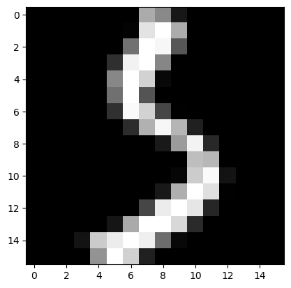

```
However, the model said this image was 6


below we can see the image of one missclassified observation. Which its true value is 5
```

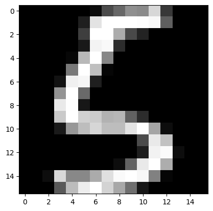

```
However, the model said this image was 6


below we can see the image of one missclassified observation. Which its true value is 5
```

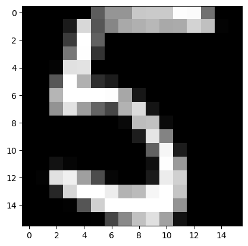

```
However, the model said this image was 6


below we can see the image of one missclassified observation. Which its true value is 5
```

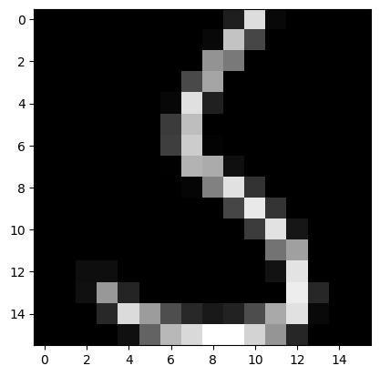

```
However, the model said this image was 6


below we can see the image of one missclassified observation. Which its true value is 5
```

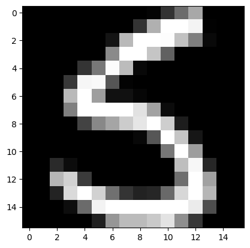

```
However, the model said this image was 6


below we can see the image of one missclassified observation. Which its true value is 5
```

[57 more figures not shown]

```
However, the model said this image was 5
```

```python
'''

Now, let's just do a loop to print all misclassified observations.
So that we can check more of them quickly, and have more visual examples to
make conclusions.

'''
for index in range(0,len(missclassified_indexes)):
    # grab the pixels of the first missclassified image
    missclassified_image=x_test_brut[missclassified_indexes[index],:]

    # plot missclassified image

    print(f'below we can see the image of one missclassified observation. Which its true value is {5 if class_test[missclassified_indexes[index]][0] == 0 else 6}')

    I = reshape(missclassified_image,(16,16))

    plt.imshow(I,cmap='gray')
    plt.show()

    print()

    print(f'However, the model said this image was {5 if decision_vector_test[missclassified_indexes[index]][0] == 0 else 6}')
    print()
    print()
```

## 3. Logistic regression using `scikit-learn`

1. **Go to** http://scikit-learn.org/stable/modules/generated/sklearn.linear_model.LogisticRegression.html for a presentation of the logistic regression model in `scikit-learn`.
2. **Apply** it to the present data set.
3. **Comment** on the use of logistic regression.

*Indication : you may have a look at*

a) Theory : http://openclassroom.stanford.edu/MainFolder/DocumentPage.php?course=MachineLearning&doc=exercises/ex5/ex5.html

b) Video : https://kr.coursera.org/lecture/machine-learning/regularized-logistic-regression-cAxpF

c) Example : http://scikit-learn.org/stable/auto_examples/exercises/plot_digits_classification_exercise.html#sphx-glr-auto-examples-exercises-plot-digits-classification-exercise-py

*for a short presentation of regularized logistic regression.*

#### 3.2.1 Application of logistic regression to synthetic data

```python
# The predictions using the implemented regression_logistique function
Nitermax = 50; eps_conv=1e-3;
X_train = np.hstack((np.ones((np.size(synth_train[:,1:],axis=0),1)),synth_train[:,1:]));
X_test = np.hstack((np.ones((np.size(synth_test[:,1:],axis=0),1)),synth_test[:,1:]));

# w, Niter = regression_logistique(X, t)
[w_logit,Niter] = regression_logistique(X_train,t,Nitermax,eps_conv)

y_hat_test_1 = np.where(1/(1+np.exp(-X_test.dot(w_logit)))> 0.5, 1, 0)


# The predictions using SK-learn
from sklearn.linear_model import LogisticRegression
clf = LogisticRegression()
clf.fit(synth_train[:,1:], t)

y_hat_test_2 = clf.predict(synth_test[:,1:])


# Test error
error_1 = 1-mean(t_test == y_hat_test_1)
print("The test error of logistic regression manually implemented is", error_1)

error_2 = 1-mean(t_test == y_hat_test_2)
print("The test error of SK-learn logistic regression is", error_2)
```

```
The test error of logistic regression manually implemented is 0.06000000000000005
The test error of SK-learn logistic regression is 0.06000000000000005
```

#### Conclusion: The function "regression_logistique" implemented has the same performance as the one of SK-learn in terms of test error, using synthetic data.

#### 3.2.2 Application of logistic regression to handwritten characters problem (5 & 6)

```python
# The predictions using the implemented regression_logistique function
y_hat_test_3 = decision_vector_test

# Test error
error_3 = 1-mean(class_test == y_hat_test_3)
print("The test error of logistic regression manually implemented is", error_3)

"""
We already computed this test error in the question 8 of the Exercise 2.
"""
```

```
The test error of logistic regression manually implemented is 0.07885714285714285
```

```
'\nWe already computed this test error in the question 8 of the Exercise 2.\n'
```

```python
# The predictions using SK-learn
from sklearn.linear_model import LogisticRegression
clf = LogisticRegression(tol=1e-3,C=1e100,solver='newton-cholesky',max_iter=13)
"""
Newton-Cholesky solver is combining the Newton-Raphson optimization algorithm (Iterated Reweighted Least Squares algorithm)
with the Cholesky matrix decomposition in order to approximate numerically the solution of the logistic regression optimization
problem to find an estimate of the parameter w.

Note that C = 1/lambda, where lambda is the regularization parameter added to the cost function of logistic regression.
Therefore, to minimize the effect of regularization, C has to be to very high, knowing that it's default value is 1.
"""
clf.fit(x_train, class_train.ravel())

y_hat_test_4 = clf.predict(x_test) # Predictions


# Test error
error_4 = 1-np.mean(class_test.ravel() == y_hat_test_4)
print("The test error of SK-learn logistic regression is", error_4)
```

```
The test error of SK-learn logistic regression is 0.07657142857142862
```

#### Comments : Using handwritten digits data, the logistic regression implemented in SK-learn seems to be more robust, because of the regularization which is applied by default. Although we decreased the effect of this regularization by increase the factor C (the inverse of the regularization parameter) up to 10^100 (which means that the regularization parameter is 10^-100, close to zero), it effect is not completed removed.

#### Knowing that the aim of regularization is to avoid overfitting, it is not a surprise that SK-learn algorithm performs slightly better than the regression_logistique function implemented.